# Factorial Experiment

Author

Affiliation

Undergrad Hernandes Peres

[Biometrics Lab.](https://biometria.ufv.br/)

In factorial experiments, two or more factors are studied simultaneously, and each factor has two or more levels.

- Factorial experiments are not a design themselves, but rather a scheme that represents how treatments are arranged into experimental units.
- In factorial experiments, each level of a factor must be combined with all levels of the other factor(s) to form the complete set of treatments.
- **Main Effect:** This refers to the effect of each factor (e.g., A or B) independently of the other factors. In other words, it is the change in the response variable caused by changing the levels of a given factor.
- **Interaction Effect:** This is the combined effect of multiple factors on the response variable. Interaction occurs when the effect of the levels of one factor depends on the levels of another factor.

The model for a factorial experiment under **CRD**:
$$Y_{ijk}=\mu+\alpha_i+\beta_j+(\alpha\beta)_{ij}+\varepsilon_{ijk}$$
Under **RBD**:
$$Y_{ijk}=\mu+\alpha_i+\beta_j+(\alpha\beta)_{ij}+\omega_k +\varepsilon_{ijk}$$
Under **LSD**:
$$Y_{ijk}=\mu+\alpha_i+\beta_j+(\alpha\beta)_{ij}+\lambda_r+\gamma_s+ +\varepsilon_{ijk}$$

$\text{What are we testing at a factorial experiment?}$

-$H_0:$ The factors A and B are independent with respect to the response variable;

-$H_a:$ The factors A and B are NOT independent with respect to the response variable;

So, if the interaction is **not significant**, we should continue the study by analyzing the **factors independently**.

However, if the interaction turns out to be **significant**, comparisons between the levels of one factor should be made **at each level of the other factor**, since the result indicates a meaningful interaction. In other words, the effect of one factor depends on the level of the other.

## Example 1: Non-significant Interaction (CRD)

A researcher designed a factorial experiment in a Completely Randomized Design (CRD) with 5 replications to evaluate the effect of harvest time and combine type on grain loss (kg/ha). Three harvest times (H1, H2, H3) and two types of combine harvesters (T1, T2) were tested.

```r
rm(list=ls())
# setwd("C:/StatisticsCourse/09-Fatorial")
data <- read.table("DataColheitadeiraNS.txt", header=TRUE)

data$trat <- factor(data$trat)
data$horario <- factor(data$horario)
data$tipo <- factor(data$tipo)
data$rep <- factor(data$rep)
```

### 1. Exploratory analysis

```r
# install.packages("lattice")
library(lattice)
```

By harvester type

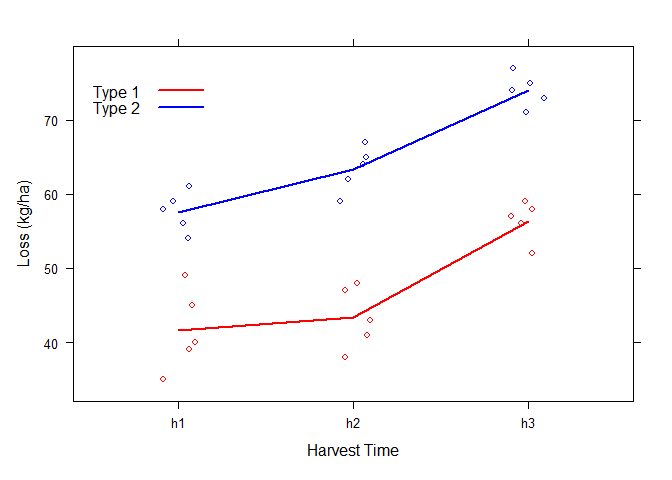

```r
xyplot(perda ~ horario,
       groups = tipo,
       data = data, jitter.x = TRUE,
       xlab = "Harvest Time", ylab = "Loss (kg/ha)", type = c("p", "a"),
       lty = c(1, 1), lwd = c(2, 2), col = c("red", "blue"),
       key = list(x = 0.02, y = 0.9, columns = 1,
                  text = list(lab = c("Type 1", "Type 2")),
                  lines = list(lty = c(1, 1), lwd = c(2, 2), col = c("red", "blue"))))
```

By harvest time

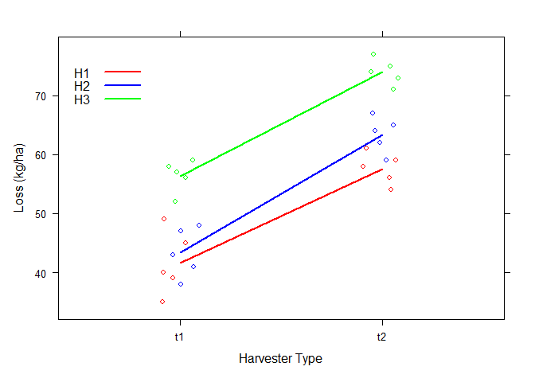

```r
xyplot(perda ~ tipo,
       groups = horario,
       data = data, jitter.x = TRUE,
       xlab = "Harvester Type", ylab = "Loss (kg/ha)", type = c("p", "a"),
       lty = 1, lwd = 2, col = c("red", "blue", "green"),
       key = list(x = 0.02, y = 0.9, columns = 1,
                  text = list(lab = c("H1", "H2", "H3")),
                  lines = list(lty = 1, lwd = 2, col = c("red", "blue", "green"))))
```

When the lines are parallel or approximately parallel, it indicates that the interaction is **not significant**.

### 2. Field layout

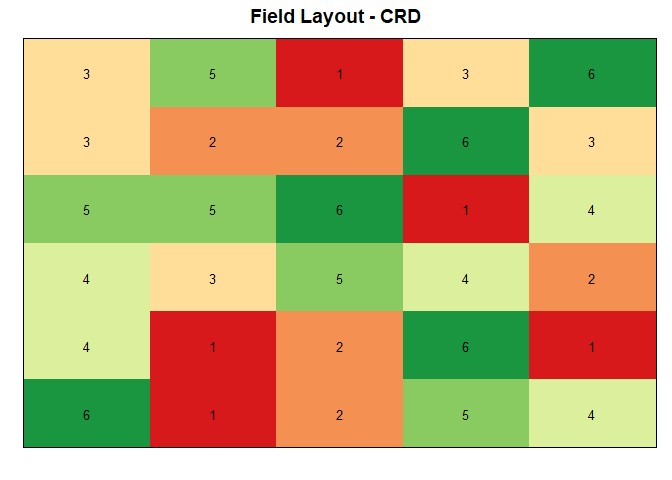

```r
source("C:/StatisticsCourse/05-DIC/ExperimentalDesignFunction.R")

set.seed(7)
field_layout(data = data,
             n_row = nrow(data)/length(levels(data$rep)),
             n_col = length(levels(data$rep)),
             design = "CRD")$plot
```

### 3. Assumption Checks

```r
fit1 <- aov(data$perda ~ data$trat)
anova(fit1)
```

```
Analysis of Variance Table

Response: data$perda
          Df Sum Sq Mean Sq F value    Pr(>F)
data$trat  5 3737.9  747.57  59.019 1.067e-12 ***
Residuals 24  304.0   12.67
---
Signif. codes:  0 '***' 0.001 '**' 0.01 '*' 0.05 '.' 0.1 ' ' 1
```

**1.3.1 Checking normality**

```r
shapiro.test(residuals(fit1))
```

```
    Shapiro-Wilk normality test

data:  residuals(fit1)
W = 0.98934, p-value = 0.9874
```

**1.3.2 Checking residual homoscedasticity**

```r
bartlett.test(residuals(fit1) ~ data$trat)
```

```
    Bartlett test of homogeneity of variances

data:  residuals(fit1) by data$trat
Bartlett's K-squared = 4.2778, df = 5, p-value = 0.5101
```

### 4. Analysis of variance

```r
fit2 <- aov(data$perda ~ data$horario * data$tipo)
anova(fit2)
```

```
Analysis of Variance Table

Response: data$perda
                       Df  Sum Sq Mean Sq F value    Pr(>F)
data$horario            2 1323.47  661.73  52.242 1.804e-09 ***
data$tipo               1 2394.13 2394.13 189.011 7.127e-13 ***
data$horario:data$tipo  2   20.27   10.13   0.800     0.461
Residuals              24  304.00   12.67
---
Signif. codes:  0 '***' 0.001 '**' 0.01 '*' 0.05 '.' 0.1 ' ' 1
```

### 5. Multiple comparisons

Analysis using `ExpDes.pt` package for it, we can use the `fat2.dic()` function

```r
library(ExpDes.pt)

fit3 <- fat2.dic(data$horario, data$tipo, data$perda,
                 quali = c(TRUE, TRUE),
                 mcomp = "tukey",
                 fac.names = c("Harvest Time", "Harvester Type"),
                 sigT = 0.05, sigF = 0.05)
```

```
------------------------------------------------------------------------
Legenda:
FATOR 1:  Harvest Time
FATOR 2:  Harvester Type
------------------------------------------------------------------------


Quadro da analise de variancia
------------------------------------------------------------------------
                            GL     SQ QM      Fc   Pr>Fc
Harvest Time                 2 1323.5  5  52.242 0.00000
Harvester Type               1 2394.1  4 189.011 0.00000
Harvest Time*Harvester Type  2   20.3  2   0.800 0.46095
Residuo                     24  304.0  3
Total                       29 4041.9  1
------------------------------------------------------------------------
CV = 6.35 %

------------------------------------------------------------------------
Teste de normalidade dos residuos (Shapiro-Wilk)
valor-p:  0.9874
De acordo com o teste de Shapiro-Wilk a 5% de significancia, os residuos podem ser considerados normais.
------------------------------------------------------------------------

Interacao nao significativa: analisando os efeitos simples
------------------------------------------------------------------------
Harvest Time
Teste de Tukey
------------------------------------------------------------------------
Grupos Tratamentos Medias
a    h3      65.2
 b   h2      53.4
 b   h1      49.6
------------------------------------------------------------------------

Harvester Type
Teste de Tukey
------------------------------------------------------------------------
Grupos Tratamentos Medias
a    t2      65
 b   t1      47.13333
------------------------------------------------------------------------
```

## Example 2: Non-significant Interaction (RCBD)

This is a factorial experiment arranged in a Randomized Complete Block Design (RCBD) to evaluate the effects of two factors (A and B) on the variable Plant Height (PH). The interaction between factors is considered non-significant.

```r
rm(list=ls())

data <- read.table("DataPH.NS.txt", header=TRUE)
data$trat <- factor(data$trat)
data$bloco <- factor(data$bloco)
data$A <- factor(data$A)
data$B <- factor(data$B)
```

### 1. Exploratory analysis

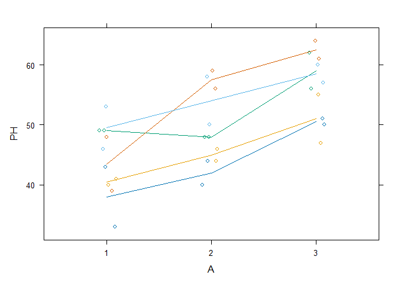

```r
library(lattice)

xyplot(PH ~ A,
       groups = B,
       data = data, jitter.x = TRUE, type = c("p", "a"))
```

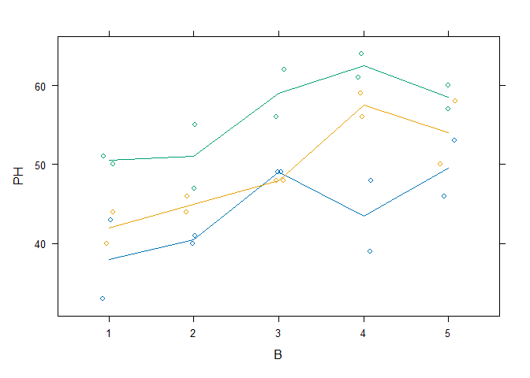

```r
xyplot(PH ~ B,
       groups = A,
       data = data, jitter.x = TRUE, type = c("p", "a"))
```

### 2. Field layout

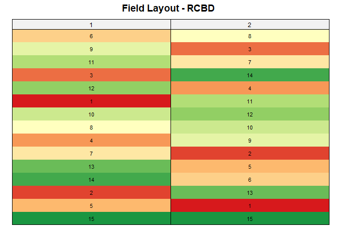

```r
source("C:/StatisticsCourse/05-DIC/ExperimentalDesignFunction.R")

set.seed(7)
field_layout(data = data,
             n_row = nrow(data)/length(levels(data$bloco)),
             n_col = length(levels(data$bloco)),
             design = "DBC")$plot
```

### 3. Assumption checking

```r
fit1 <- aov(data$PH ~ data$trat + data$bloco)
anova(fit1)
```

```
Analysis of Variance Table

Response: data$PH
           Df Sum Sq Mean Sq F value    Pr(>F)
data$trat  14 1507.2 107.657  7.2882 0.0003281 ***
data$bloco  1   14.7  14.700  0.9952 0.3354142
Residuals  14  206.8  14.771
---
Signif. codes:  0 '***' 0.001 '**' 0.01 '*' 0.05 '.' 0.1 ' ' 1
```

**Checking normality**

```r
shapiro.test(residuals(fit1))
```

```
    Shapiro-Wilk normality test

data:  residuals(fit1)
W = 0.97181, p-value = 0.5899
```

**Checking residual homoscedasticity**

```r
bartlett.test(residuals(fit1) ~ data$trat)
```

```
    Bartlett test of homogeneity of variances

data:  residuals(fit1) by data$trat
Bartlett's K-squared = 12.381, df = 14, p-value = 0.5757
```

### 4. Analysis of variance

```r
fit2 <- aov(data$PH ~ data$bloco + data$A * data$B)
anova(fit2)
```

```
Analysis of Variance Table

Response: data$PH
              Df Sum Sq Mean Sq F value    Pr(>F)
data$bloco     1   14.7   14.70  0.9952 0.3354142
data$A         2  749.6  374.80 25.3733  2.21e-05 ***
data$B         4  616.2  154.05 10.4289 0.0003947 ***
data$A:data$B  8  141.4   17.67  1.1966 0.3671283
Residuals     14  206.8   14.77
---
Signif. codes:  0 '***' 0.001 '**' 0.01 '*' 0.05 '.' 0.1 ' ' 1
```

```r
model.tables(fit2, type = "means")
```

```
Tables of means
Grand mean

49.9

 data$bloco
data$bloco
   1    2
50.6 49.2

 data$A
data$A
   1    2    3
44.1 49.3 56.3

 data$B
data$B
   1    2    3    4    5
43.5 45.5 52.0 54.5 54.0

 data$A:data$B
      data$B
data$A 1    2    3    4    5
     1 38.0 40.5 49.0 43.5 49.5
     2 42.0 45.0 48.0 57.5 54.0
     3 50.5 51.0 59.0 62.5 58.5
```

### 5. Multiple comparisons

```r
library(ExpDes.pt)

fit3 <- fat2.dbc(data$A, data$B, data$bloco, data$PH,
                 quali = c(TRUE, TRUE),
                 mcomp = "tukey",
                 fac.names = c("A", "B"),
                 sigT = 0.05, sigF = 0.05)
```

```
------------------------------------------------------------------------
Legenda:
FATOR 1:  A
FATOR 2:  B
------------------------------------------------------------------------


Quadro da analise de variancia
------------------------------------------------------------------------
        GL     SQ QM      Fc   Pr>Fc
Bloco    1   14.7  2  0.9952 0.33541
A        2  749.6  6 25.3733 0.00002
B        4  616.2  4 10.4289 0.00039
A*B      8  141.4  5  1.1966 0.36713
Residuo 14  206.8  3
Total   29 1728.7  1
------------------------------------------------------------------------
CV = 7.7 %

------------------------------------------------------------------------
Teste de normalidade dos residuos (Shapiro-Wilk)
valor-p:  0.5899367
De acordo com o teste de Shapiro-Wilk a 5% de significancia, os residuos podem ser considerados normais.
------------------------------------------------------------------------

Interacao nao significativa: analisando os efeitos simples
------------------------------------------------------------------------
A
Teste de Tukey
------------------------------------------------------------------------
Grupos Tratamentos Medias
a    3   56.3
 b   2   49.3
  c      1   44.1
------------------------------------------------------------------------

B
Teste de Tukey
------------------------------------------------------------------------
Grupos Tratamentos Medias
a    4   54.5
a    5   54
ab   3   52
 bc      2   45.5
  c      1   43.5
------------------------------------------------------------------------
```

## Example 3: Significant Interaction (CRD)

A factorial experiment was conducted using a Completely Randomized Design (CRD) to evaluate the effect of two factors — Container and Species — on seedling height at 80 days of age.

**Container levels:**

- Small plastic bag (R1)
- Large plastic bag (R2)
- Laminated bag (R3)

**Species levels:**

- *Eucalyptus citriodora* (E1)
- *Eucalyptus grandis* (E2)

```r
rm(list=ls())
data <- read.table("DataSignif.txt", header=TRUE)
data$trat <- factor(data$trat)
data$R <- factor(data$R)
data$E <- factor(data$E)
data$rep <- factor(data$rep)

knitr::kable(data)
```

| trat | R | E | rep | alt |
| --- | --- | --- | --- | --- |
| 1 | 1 | 1 | 1 | 26.2 |
| 1 | 1 | 1 | 2 | 26.0 |
| 1 | 1 | 1 | 3 | 25.0 |
| 1 | 1 | 1 | 4 | 25.4 |
| 2 | 1 | 2 | 1 | 24.8 |
| 2 | 1 | 2 | 2 | 24.6 |
| 2 | 1 | 2 | 3 | 26.7 |
| 2 | 1 | 2 | 4 | 25.2 |
| 3 | 2 | 1 | 1 | 25.7 |
| 3 | 2 | 1 | 2 | 26.3 |
| 3 | 2 | 1 | 3 | 25.1 |
| 3 | 2 | 1 | 4 | 26.4 |
| 4 | 2 | 2 | 1 | 19.6 |
| 4 | 2 | 2 | 2 | 21.1 |
| 4 | 2 | 2 | 3 | 19.0 |
| 4 | 2 | 2 | 4 | 18.6 |
| 5 | 3 | 1 | 1 | 22.8 |
| 5 | 3 | 1 | 2 | 19.4 |
| 5 | 3 | 1 | 3 | 18.8 |
| 5 | 3 | 1 | 4 | 19.2 |
| 6 | 3 | 2 | 1 | 19.8 |
| 6 | 3 | 2 | 2 | 21.4 |
| 6 | 3 | 2 | 3 | 22.8 |
| 6 | 3 | 2 | 4 | 21.3 |

### 1. Exploratory analysis

```r
library(lattice)
```

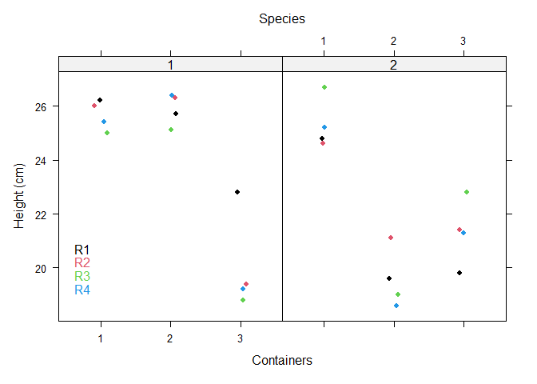

```r
xyplot(alt ~ R | E,
       groups = rep,
       data = data,
       layout = c(2,1), jitter.x = TRUE,
       xlab = "Containers",
       xlab.top = "Species",
       ylab = "Height (cm)", pch = 16,
       lwd = c(2,2,2,2), col = c(1,2,3,4),
       key = list(x = 0.02, y = 0.3, columns = 1,
                  text = list(lab = c("R1","R2","R3","R4")),
                  lwd = 2, col = c(1,2,3,4)))
```

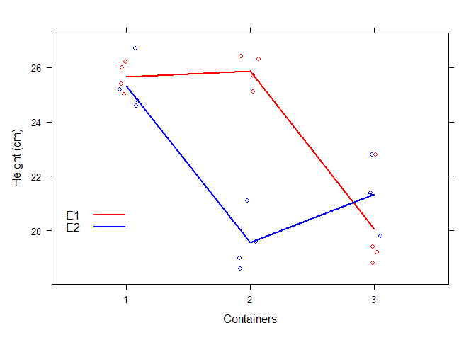

```r
xyplot(alt ~ R,
       groups = E,
       data = data,
       jitter.x = TRUE,
       xlab = "Containers",
       ylab = "Height (cm)",
       type = c("p", "a"),
       lty = c(1,1), lwd = c(2,2),
       col = c("red","blue"),
       key = list(x = 0.02, y = 0.3, columns = 1,
                  text = list(lab = c("E1","E2")),
                  lines = list(lty = c(1,1),
                               lwd = c(2,2),
                               col = c("red","blue"))))
```

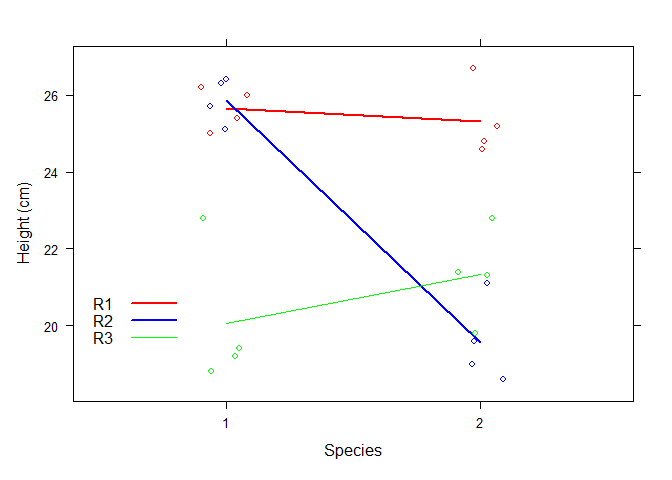

```r
xyplot(alt ~ E,
       groups = R,
       data = data,
       jitter.x = TRUE,
       xlab = "Species",
       ylab = "Height (cm)",
       type = c("p", "a"),
       lty = c(1,1,1), lwd = c(2,2,1),
       col = c("red","blue","green"),
       key = list(x = 0.02, y = 0.3, columns = 1,
                  text = list(lab = c("R1","R2","R3")),
                  lines = list(lty = c(1,1,1),
                               lwd = c(2,2,1),
                               col = c("red","blue","green"))))
```

When the lines are **not** parallel or approximately parallel, it indicates that the interaction is **significant**.

### 2. Field layout

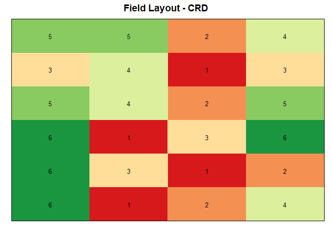

```r
source("C:/StatisticsCourse/05-DIC/ExperimentalDesignFunction.R")

set.seed(7)
field_layout(data = data,
             n_row = nrow(data)/length(levels(data$rep)),
             n_col = length(levels(data$rep)),
             design = "DIC")$plot
```

### 3. Assumption Checking

```r
fit1 <- aov(data$alt ~ data$R * data$E)
anova(fit1)
```

```
Analysis of Variance Table

Response: data$alt
              Df Sum Sq Mean Sq F value    Pr(>F)
data$R         2 92.861  46.430  36.195 4.924e-07 ***
data$E         1 19.082  19.082  14.875  0.001155 **
data$R:data$E  2 63.761  31.880  24.853 6.635e-06 ***
Residuals     18 23.090   1.283
---
Signif. codes:  0 '***' 0.001 '**' 0.01 '*' 0.05 '.' 0.1 ' ' 1
```

```r
shapiro.test(residuals(fit1))
```

```
    Shapiro-Wilk normality test

data:  residuals(fit1)
W = 0.9293, p-value = 0.09402
```

```r
bartlett.test(residuals(fit1) ~ data$trat)
```

```
    Bartlett test of homogeneity of variances

data:  residuals(fit1) by data$trat
Bartlett's K-squared = 5.2644, df = 5, p-value = 0.3845
```

### 4. ANOVA - Interaction effect

```r
fit2 <- aov(data$alt ~ data$E * data$R)
anova(fit2)
```

```
Analysis of Variance Table

Response: data$alt
              Df Sum Sq Mean Sq F value    Pr(>F)
data$E         1 19.082  19.082  14.875  0.001155 **
data$R         2 92.861  46.430  36.195 4.924e-07 ***
data$E:data$R  2 63.761  31.880  24.853 6.635e-06 ***
Residuals     18 23.090   1.283
---
Signif. codes:  0 '***' 0.001 '**' 0.01 '*' 0.05 '.' 0.1 ' ' 1
```

```r
model.tables(fit2, type = "means", se = TRUE)
```

```
Tables of means
Grand mean

22.96667

 data$E
data$E
     1      2
23.858 22.075

 data$R
data$R
     1      2      3
25.487 22.725 20.687

 data$E:data$R
      data$R
data$E 1      2      3
     1 25.650 25.875 20.050
     2 25.325 19.575 21.325

Standard errors for differences of means
        data$E data$R data$E:data$R
        0.4624 0.5663        0.8009
replic.     12      8             4
```

### 5. Multiple comparison

```r
library(ExpDes.pt)

fit3 <- fat2.dic(data$R,
                 data$E,
                 data$alt,
                 quali = c(TRUE, TRUE), mcomp = "tukey",
                 fac.names = c("Containers", "Species"),
                 sigT = 0.01, sigF = 0.01)
```

```
------------------------------------------------------------------------
Legenda:
FATOR 1:  Containers
FATOR 2:  Species
------------------------------------------------------------------------


Quadro da analise de variancia
------------------------------------------------------------------------
                   GL      SQ QM     Fc      Pr>Fc
Containers          2  92.861  5 36.195 0.00000049
Species             1  19.082  3 14.875 0.00115535
Containers*Species  2  63.761  4 24.853 0.00000664
Residuo            18  23.090  2
Total              23 198.793  1
------------------------------------------------------------------------
CV = 4.93 %

------------------------------------------------------------------------
Teste de normalidade dos residuos (Shapiro-Wilk)
valor-p:  0.09401682
De acordo com o teste de Shapiro-Wilk a 5% de significancia, os residuos podem ser considerados normais.
------------------------------------------------------------------------



Interacao significativa: desdobrando a interacao
------------------------------------------------------------------------

Desdobrando  Containers  dentro de cada nivel de  Species
------------------------------------------------------------------------
------------------------------------------------------------------------
Quadro da analise de variancia
------------------------------------------------------------------------
                     GL        SQ       QM      Fc  Pr.Fc
Species               1  19.08167 19.08167 14.8753 0.0012
Containers:Species 1  2  87.12167 43.56083 33.9582      0
Containers:Species 2  2  69.50000 34.75000 27.0896      0
Residuo              18  23.09000  1.28278
Total                23 198.79333  8.64319
```

[output cut: 56 more lines]

```
------------------------------------------------------------------------
Grupos Tratamentos Medias
a    1   25.875
 b   2   19.575
------------------------------------------------------------------------


 Species  dentro do nivel  3  de  Containers

De acordo com o teste F, as medias desse fator sao estatisticamente iguais.
------------------------------------------------------------------------
  Niveis Medias
1      1 20.050
2      2 21.325
------------------------------------------------------------------------
```